# Sesion 2: LMM

# 1 Introducción

En esta sesión continuaremos con los modelos LMM y desarrollaremos un modelo jerárquico para el análisis intimate partner violence (IPV) con datos de Ecuador (ENVIGMU, 2019)

Antes de ejecutar este documento, instala los paquetes necesarios. Copia y pega el siguiente código en la consola de R:

install.packages (c(“foreign”, “ggplot”, “dplyr”,“car”, “performance”, stargazer”, “lme4”, “sandwich”, “corrplot”))

# 2 Cargar librerias y datos

En esta primera parte, cargaremos y exploraremos los datos que usaremos para la práctica. No necesitas escribir código: todos los comandos ya están listos para ejecutarse en R.

```r
library(foreign)
library(ggplot2)
library(dplyr)
library(corrplot)
library(performance)
library(car)
library(stargazer)
library(lme4)
library(lattice)
library(sandwich)


# URL RAW del archivo en GitHub
url <- "https://raw.githubusercontent.com/edwinbhec5-glitch/sesion1_LMM/main/base_final2.sav"

# Descargar a un archivo temporal
temp_file <- tempfile(fileext = ".sav")
download.file(url, destfile = temp_file, mode = "wb")

# Leer con base
base <- read.spss(file=temp_file,
                    use.value.labels = TRUE,
                    to.data.frame = TRUE)
```

# 3 Análisis exploratorio

## 3.1 Variables cualitativas

### 3.1.1 Prevalencia de Violencia de género x area

La prevalencia de violencia es similar en áreas urbanas y rurales, aunque ligeramente mayor en el campo. Esto sugiere que la violencia no es un fenómeno exclusivo de un contexto geográfico, sino que aparece en ambas áreas.

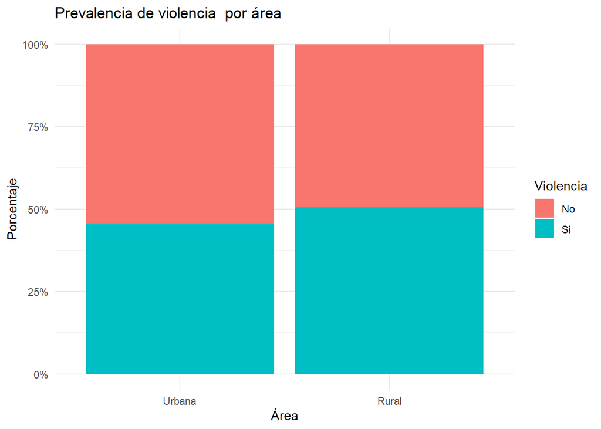

```r
base %>%
  count(area, Violencia2) %>%
  group_by(area) %>%
  mutate(pct = n / sum(n)) %>%
  ggplot(aes(x = area, y = pct, fill = Violencia2)) +
  geom_col(position = "fill") +
  scale_y_continuous(labels = scales::percent) +
  labs(
    x = "Área",
    y = "Porcentaje",
    fill = "Violencia",
    title = "Prevalencia de violencia  por área"
  ) +
  theme_minimal()
```

### 3.1.2 Prevalencia de Violencia de género x nivel educación

Se observa que a medida que aumenta el nivel educativo, disminuye la prevalencia de violencia, lo que sugiere el efecto positivo que puede tener la educación para reducir esta problemática.

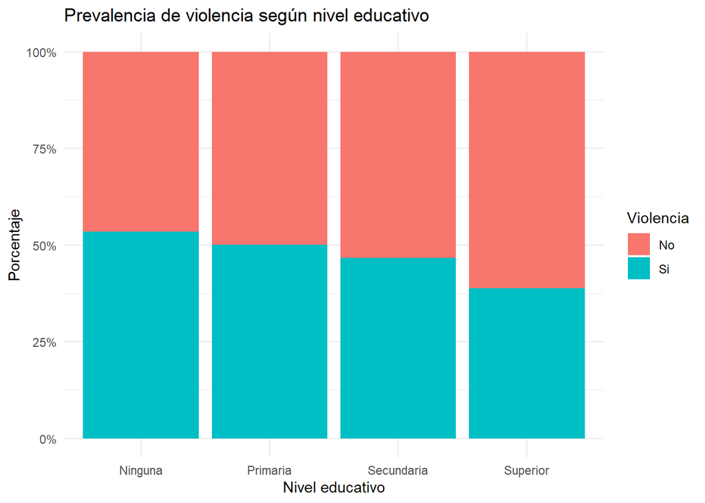

### 3.1.3 Prevalencia de Violencia de género x etnia

A nivel étnico se observan diferencias entre grupos, por ejemplo, mujeres indígenas reportan mayor prevalencia de violencia, mientras que en otros grupos, como montubias y blancas, las tasas son menores.

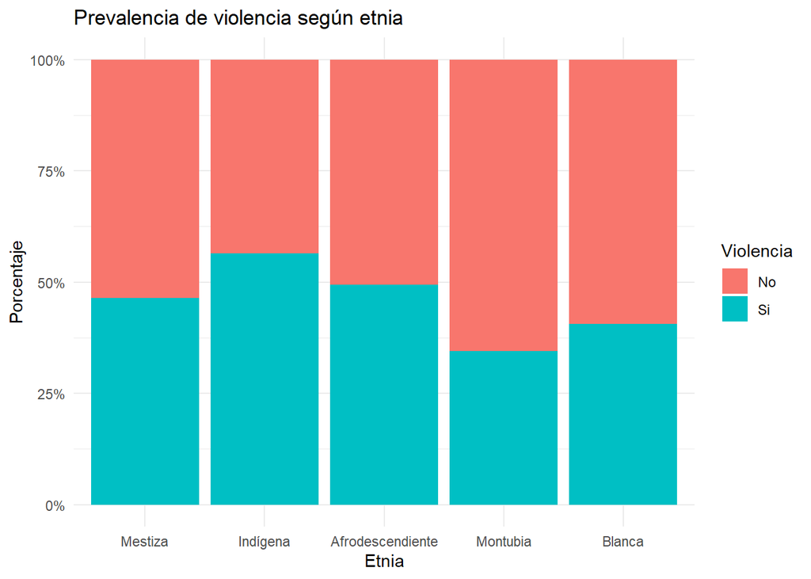

### 3.1.4 Prevalencia de Violencia de género x trabajo

Las mujeres que trabajan reportan más violencia que las que no lo hacen. Esto puede deberse a tensiones asociadas con la participación laboral o a diferencias en la independencia económica. El modelo servirá para explorar si este efecto se mantiene al controlar por otras variables.

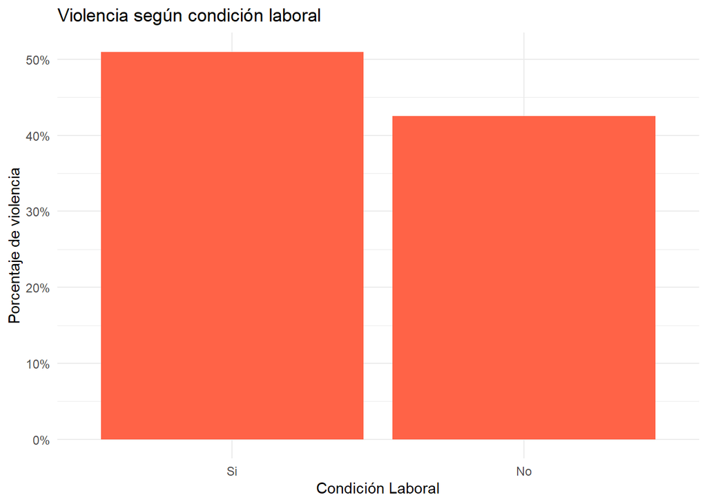

## 3.2 Análisis exploratorio variables cuantitativas

### 3.2.1 Variables individuales

Variable como la edad de la mujer y en especial el número de hijos, parecen mostrar diferencias entre quienes han sido victimas de violencia de género por parte de sus parejas.

```
# A tibble: 2 × 3
  Violencia2 edad_media hijos_medio
  <fct>           <dbl>       <dbl>
1 No               45.7        1.79
2 Si               47.5        2.11
```

### 3.2.2 Variables relacionales y roles género

Algo similar sucede con la transmisión intergeneracional de la violencia. El hecho de haber sufrido Violencia de Género en la familia de orígen de la encuestada (IFOV_M), así como que su pareja se haya criado en un hogar donde existía violencia de género (IFOV_P), parecen marcar una diferencia. De igual forma, las creencias culturales relacionadas a los roles de género parecen influir en esta problemática.

```
# A tibble: 2 × 4
  Violencia2 IFOV_M_medio IFOV_P_medio IRG_medio
  <fct>             <dbl>        <dbl>     <dbl>
1 No                 1.21        0.553      4.71
2 Si                 2.31        1.22       5.26
```

## 3.3 Matriz de correlaciones

No parecen existir fuertes correlaciones lineales entre las variables seleccionadas, por lo que los problemas de multicolinealidad serían menores.

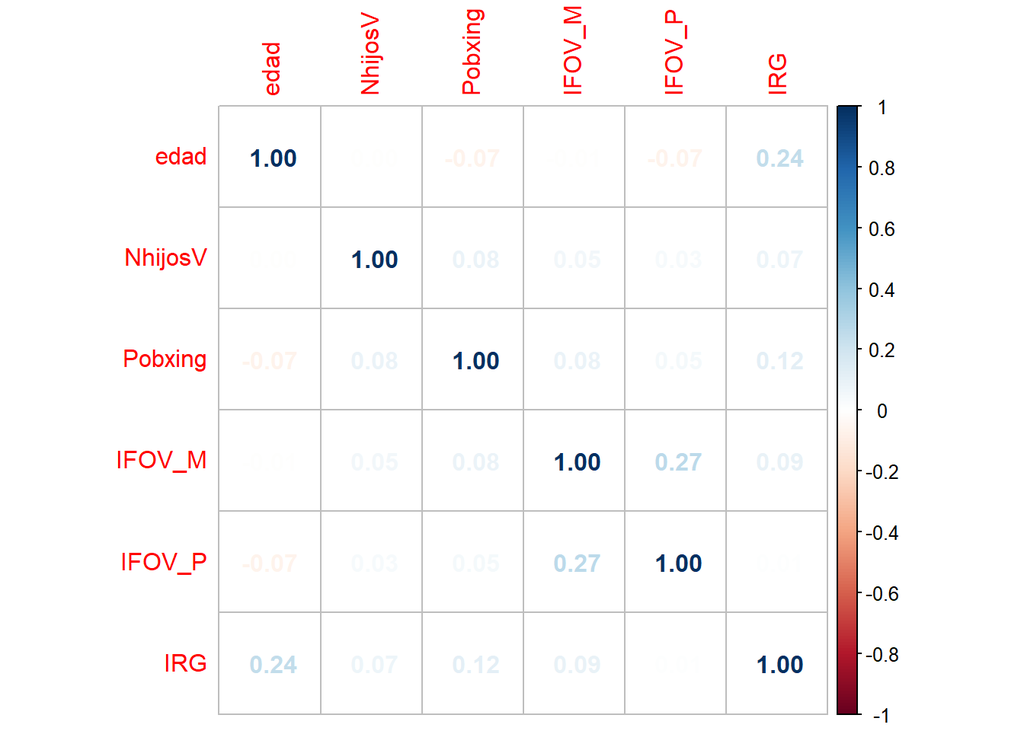

# 4 Modelización

## 4.1 Definición de referencias para variables cualitativas

```r
base$area=relevel(base$area,ref="Urbana")
base$estado_civil=relevel(base$estado_civil2,ref="Casadas")
base$educacion2=relevel(base$educacion2,ref="Superior")
base$etnia2=relevel(base$etnia2,ref="Mestiza")
```

## 4.2 Modelo logit básico

Este modelo no considera el contexto jerárquico de los datos, pero permite analizar las relaciones existentes entre la violencia de género en pareja y distintos factores que podrían explicar este problema.

```r
logit <- glm(Violencia2 ~ edad_z+NhijosV_z+area+estado_civil2+educacion2+etnia2+trabaja2019+Pobxing_z+
               IFOV_M_z+IFOV_P_z+IRG_z, data = base, family = binomial(link = "logit"))

summary(logit)
```

```
Call:
glm(formula = Violencia2 ~ edad_z + NhijosV_z + area + estado_civil2 +
    educacion2 + etnia2 + trabaja2019 + Pobxing_z + IFOV_M_z +
    IFOV_P_z + IRG_z, family = binomial(link = "logit"), data = base)

Coefficients:
                        Estimate Std. Error z value Pr(>|z|)
(Intercept)             -0.35761    0.05248  -6.815 9.46e-12 ***
edad_z                   0.02873    0.02243   1.281 0.200346
NhijosV_z                0.06470    0.01906   3.395 0.000687 ***
areaRural                0.03944    0.04203   0.938 0.348001
estado_civil2Unidas     -0.15461    0.04652  -3.323 0.000889 ***
estado_civil2Sin pareja  0.75017    0.04720  15.894  < 2e-16 ***
educacion2Ninguna        0.16094    0.09258   1.738 0.082150 .
educacion2Primaria       0.24981    0.05955   4.195 2.73e-05 ***
educacion2Secundaria     0.28031    0.05614   4.993 5.94e-07 ***
etnia2Indígena           0.13656    0.06284   2.173 0.029760 *
etnia2Afrodescendiente  -0.04903    0.10134  -0.484 0.628543
etnia2Montubia          -0.37864    0.12455  -3.040 0.002365 **
etnia2Blanca            -0.24191    0.12000  -2.016 0.043817 *
trabaja2019No           -0.26006    0.03798  -6.847 7.54e-12 ***
Pobxing_z                0.02536    0.01938   1.309 0.190573
IFOV_M_z                 0.38471    0.01968  19.551  < 2e-16 ***
IFOV_P_z                 0.39817    0.01935  20.578  < 2e-16 ***
IRG_z                    0.14440    0.02043   7.068 1.57e-12 ***
---
Signif. codes:  0 '***' 0.001 '**' 0.01 '*' 0.05 '.' 0.1 ' ' 1

(Dispersion parameter for binomial family taken to be 1)

    Null deviance: 19459  on 14065  degrees of freedom
Residual deviance: 17543  on 14048  degrees of freedom
AIC: 17579

Number of Fisher Scoring iterations: 4
```

## 4.3 Modelos Jerarquicos

### 4.3.1 Nulo

```r
jerarquico0 <- glmer(
  Violencia2 ~ 1 + (1 | prov/upm),
  data = base,
  family = binomial(link = "logit"))

summary(jerarquico0)
```

```
Generalized linear mixed model fit by maximum likelihood (Laplace
  Approximation) [glmerMod]
 Family: binomial  ( logit )
Formula: Violencia2 ~ 1 + (1 | prov/upm)
   Data: base

     AIC      BIC   logLik deviance df.resid
 18845.4  18868.0  -9419.7  18839.4    14063

Scaled residuals:
    Min      1Q  Median      3Q     Max
-1.6003 -0.8513 -0.5786  0.9171  1.7682

Random effects:
 Groups   Name        Variance Std.Dev.
 upm:prov (Intercept) 0.3625   0.6021
 prov     (Intercept) 0.1912   0.4373
Number of obs: 14066, groups:  upm:prov, 2594; prov, 24

Fixed effects:
            Estimate Std. Error z value Pr(>|z|)
(Intercept) -0.07372    0.09208  -0.801    0.423
```

```r
performance::icc(jerarquico0)
```

```
# Intraclass Correlation Coefficient

    Adjusted ICC: 0.144
  Unadjusted ICC: 0.144
```

Se observa que la mayor parte de la variabilidad contextual está en las UPM. Esto indica que las diferencias entre unidades primarias de muestreo (barrios, sectores) son más relevantes que las diferencias entre provincias. Si bien el nivel provincial aporta variabilidad, esto es menor.

En otras palabras el contexto regional importa, pero el microcontexto inmediato (UPM) pesa más.

Se observa que el Coeficiente de Correlacion Intraclase es de 0.144 significa que alrededor del 14% de la varianza total en la violencia de pareja se explica por diferencias entre contextos (UPM y provincias), lo que justifica plenamente un modelo jerárquico.

### 4.3.2 Var individuales + contexto provincial (pobreza)

```r
jerarquico1 <- glmer(
  Violencia ~ edad_z+NhijosV_z+area+estado_civil2+educacion2+etnia2+trabaja2019+Pobxing_z+
    (1 | prov/upm),
  data = base,
  family = binomial(link = "logit"))
summary(jerarquico1)
```

```
Generalized linear mixed model fit by maximum likelihood (Laplace
  Approximation) [glmerMod]
 Family: binomial  ( logit )
Formula: Violencia ~ edad_z + NhijosV_z + area + estado_civil2 + educacion2 +
    etnia2 + trabaja2019 + Pobxing_z + (1 | prov/upm)
   Data: base

     AIC      BIC   logLik deviance df.resid
 18258.8  18387.2  -9112.4  18224.8    14049

Scaled residuals:
    Min      1Q  Median      3Q     Max
-2.5888 -0.8057 -0.5015  0.8707  2.3216

Random effects:
 Groups   Name        Variance Std.Dev.
 upm:prov (Intercept) 0.3723   0.6102
 prov     (Intercept) 0.1602   0.4002
Number of obs: 14066, groups:  upm:prov, 2594; prov, 24

Fixed effects:
                         Estimate Std. Error z value Pr(>|z|)
(Intercept)             -0.569693   0.099572  -5.721 1.06e-08 ***
edad_z                  -0.003301   0.023490  -0.141   0.8883
NhijosV_z                0.082167   0.020195   4.069 4.73e-05 ***
areaRural                0.014211   0.053530   0.265   0.7906
estado_civil2Unidas     -0.115415   0.049856  -2.315   0.0206 *
estado_civil2Sin pareja  0.819574   0.049829  16.448  < 2e-16 ***
educacion2Ninguna        0.491198   0.097578   5.034 4.81e-07 ***
educacion2Primaria       0.520724   0.061948   8.406  < 2e-16 ***
educacion2Secundaria     0.445274   0.058677   7.589 3.24e-14 ***
etnia2Indígena           0.120753   0.072659   1.662   0.0965 .
etnia2Afrodescendiente   0.064821   0.117389   0.552   0.5808
etnia2Montubia          -0.214055   0.134804  -1.588   0.1123
etnia2Blanca            -0.267426   0.125073  -2.138   0.0325 *
trabaja2019No           -0.245111   0.040376  -6.071 1.27e-09 ***
Pobxing_z                0.109357   0.080534   1.358   0.1745
---
Signif. codes:  0 '***' 0.001 '**' 0.01 '*' 0.05 '.' 0.1 ' ' 1
```

```
Correlation matrix not shown by default, as p = 15 > 12.
Use print(x, correlation=TRUE)  or
    vcov(x)        if you need it
```

```
optimizer (Nelder_Mead) convergence code: 0 (OK)
Model failed to converge with max|grad| = 0.00415716 (tol = 0.002, component 1)
```

```r
performance::icc(jerarquico1)
```

```
# Intraclass Correlation Coefficient

    Adjusted ICC: 0.139
  Unadjusted ICC: 0.131
```

Al añadir variables individuales y la pobreza provincial, la varianza entre provincias disminuye. Esto significa que parte de las diferencias territoriales se explica por estas variables, aunque la pobreza en sí no resulta estadísticamente significativa.

### 4.3.3 Var individuales + pobreza + IFOV + IRGN

```r
jerarquico2 <- glmer(
  Violencia ~ edad_z+NhijosV_z+area+estado_civil2+educacion2+etnia2+trabaja2019+Pobxing_z+
    IFOV_M_z+IFOV_P_z+IRG_z+(1 | prov/upm),
  data = base,
  family = binomial(link = "logit"))
summary(jerarquico2)
```

```
Generalized linear mixed model fit by maximum likelihood (Laplace
  Approximation) [glmerMod]
 Family: binomial  ( logit )
Formula: Violencia ~ edad_z + NhijosV_z + area + estado_civil2 + educacion2 +
    etnia2 + trabaja2019 + Pobxing_z + IFOV_M_z + IFOV_P_z +
    IRG_z + (1 | prov/upm)
   Data: base

     AIC      BIC   logLik deviance df.resid
 17288.5  17439.5  -8624.2  17248.5    14046

Scaled residuals:
    Min      1Q  Median      3Q     Max
-4.6524 -0.7425 -0.4408  0.8253  2.4539

Random effects:
 Groups   Name        Variance Std.Dev.
 upm:prov (Intercept) 0.3063   0.5534
 prov     (Intercept) 0.1097   0.3312
Number of obs: 14066, groups:  upm:prov, 2594; prov, 24

Fixed effects:
                         Estimate Std. Error z value Pr(>|z|)
(Intercept)             -0.435118   0.089832  -4.844 1.27e-06 ***
edad_z                   0.022082   0.024266   0.910  0.36283
NhijosV_z                0.064135   0.020512   3.127  0.00177 **
areaRural                0.006736   0.053444   0.126  0.89970
estado_civil2Unidas     -0.116641   0.051034  -2.286  0.02228 *
estado_civil2Sin pareja  0.837031   0.051169  16.358  < 2e-16 ***
educacion2Ninguna        0.254090   0.101498   2.503  0.01230 *
educacion2Primaria       0.319700   0.065360   4.891 1.00e-06 ***
educacion2Secundaria     0.330649   0.060477   5.467 4.57e-08 ***
etnia2Indígena           0.062689   0.074285   0.844  0.39873
etnia2Afrodescendiente   0.019799   0.119204   0.166  0.86808
etnia2Montubia          -0.208910   0.136786  -1.527  0.12669
etnia2Blanca            -0.253024   0.127875  -1.979  0.04785 *
trabaja2019No           -0.217295   0.041388  -5.250 1.52e-07 ***
Pobxing_z                0.062787   0.067993   0.923  0.35578
IFOV_M_z                 0.380525   0.021259  17.900  < 2e-16 ***
IFOV_P_z                 0.404186   0.020809  19.424  < 2e-16 ***
IRG_z                    0.122215   0.022211   5.503 3.74e-08 ***
---
Signif. codes:  0 '***' 0.001 '**' 0.01 '*' 0.05 '.' 0.1 ' ' 1
```

```
Correlation matrix not shown by default, as p = 18 > 12.
Use print(x, correlation=TRUE)  or
    vcov(x)        if you need it
```

```
optimizer (Nelder_Mead) convergence code: 0 (OK)
Model failed to converge with max|grad| = 0.00665649 (tol = 0.002, component 1)
```

```r
performance::icc(jerarquico2)
```

```
# Intraclass Correlation Coefficient

    Adjusted ICC: 0.112
  Unadjusted ICC: 0.095
```

Cuando se agregan indicadores de violencia en la familia de origen (IFOV) y roles de género (IRG), estos son altamente significativos y reducen aún más la varianza entre provincias. Esto muestra que la historia familiar y las creencias de género son factores clave para entender la violencia.

## 4.4 Comparación de modelos

```r
anova(jerarquico0, jerarquico1,jerarquico2, logit, test = "LRT")
```

```
Data: base
Models:
jerarquico0: Violencia2 ~ 1 + (1 | prov/upm)
jerarquico1: Violencia ~ edad_z + NhijosV_z + area + estado_civil2 + educacion2 + etnia2 + trabaja2019 + Pobxing_z + (1 | prov/upm)
logit: Violencia2 ~ edad_z + NhijosV_z + area + estado_civil2 + educacion2 + etnia2 + trabaja2019 + Pobxing_z + IFOV_M_z + IFOV_P_z + IRG_z
jerarquico2: Violencia ~ edad_z + NhijosV_z + area + estado_civil2 + educacion2 + etnia2 + trabaja2019 + Pobxing_z + IFOV_M_z + IFOV_P_z + IRG_z + (1 | prov/upm)
            npar   AIC   BIC  logLik deviance  Chisq Df Pr(>Chisq)
jerarquico0    3 18845 18868 -9419.7    18839
jerarquico1   17 18259 18387 -9112.4    18225 614.57 14  < 2.2e-16 ***
logit         18 17579 17714 -8771.3    17543 682.28  1  < 2.2e-16 ***
jerarquico2   20 17289 17440 -8624.2    17249 294.06  2  < 2.2e-16 ***
---
Signif. codes:  0 '***' 0.001 '**' 0.01 '*' 0.05 '.' 0.1 ' ' 1
```

```r
stargazer(jerarquico0, jerarquico1, jerarquico2, logit,
          type = "text",
          summary=F,
          title = "Modelos IPV")
```

```
Modelos IPV
===========================================================================
                                        Dependent variable:
                        ---------------------------------------------------
                            Violencia2           Violencia       Violencia2
                        generalized linear  generalized linear    logistic
                          mixed-effects        mixed-effects
                               (1)            (2)        (3)        (4)
---------------------------------------------------------------------------
edad_z                                       -0.003     0.022      0.029
                                            (0.023)    (0.024)    (0.022)

NhijosV_z                                   0.082***   0.064***   0.065***
                                            (0.020)    (0.021)    (0.019)

areaRural                                    0.014      0.007      0.039
                                            (0.054)    (0.053)    (0.042)

estado_civil2Unidas                         -0.115**   -0.117**  -0.155***
                                            (0.050)    (0.051)    (0.047)

estado_civil2Sin pareja                     0.820***   0.837***   0.750***
                                            (0.050)    (0.051)    (0.047)

educacion2Ninguna                           0.491***   0.254**     0.161*
                                            (0.098)    (0.101)    (0.093)

educacion2Primaria                          0.521***   0.320***   0.250***
                                            (0.062)    (0.065)    (0.060)

educacion2Secundaria                        0.445***   0.331***   0.280***
                                            (0.059)    (0.060)    (0.056)

etnia2Indígena                               0.121*     0.063     0.137**
                                            (0.073)    (0.074)    (0.063)

etnia2Afrodescendiente                       0.065      0.020      -0.049
                                            (0.117)    (0.119)    (0.101)

etnia2Montubia                               -0.214     -0.209   -0.379***
```

[output cut: 15 more lines]

```
                                                       (0.021)    (0.019)

IRG_z                                                  0.122***   0.144***
                                                       (0.022)    (0.020)

Constant                      -0.074       -0.570***  -0.435***  -0.358***
                             (0.092)        (0.100)    (0.090)    (0.052)

---------------------------------------------------------------------------
Observations                  14,066         14,066     14,066     14,066
Log Likelihood              -9,419.682     -9,112.395 -8,624.226 -8,771.254
Akaike Inf. Crit.           18,845.360     18,258.790 17,288.450 17,578.510
Bayesian Inf. Crit.         18,868.020     18,387.170 17,439.480
===========================================================================
Note:                                           *p<0.1; **p<0.05; ***p<0.01
```

La comparación de modelos muestra que cada paso mejora el ajuste (AIC más bajo). El modelo jerárquico completo (jerarquico2) explica mejor los datos que el logit sin jerarquía, confirmando la importancia de los niveles territoriales.

## 4.5 Pruebas

```
$`upm:prov`
```

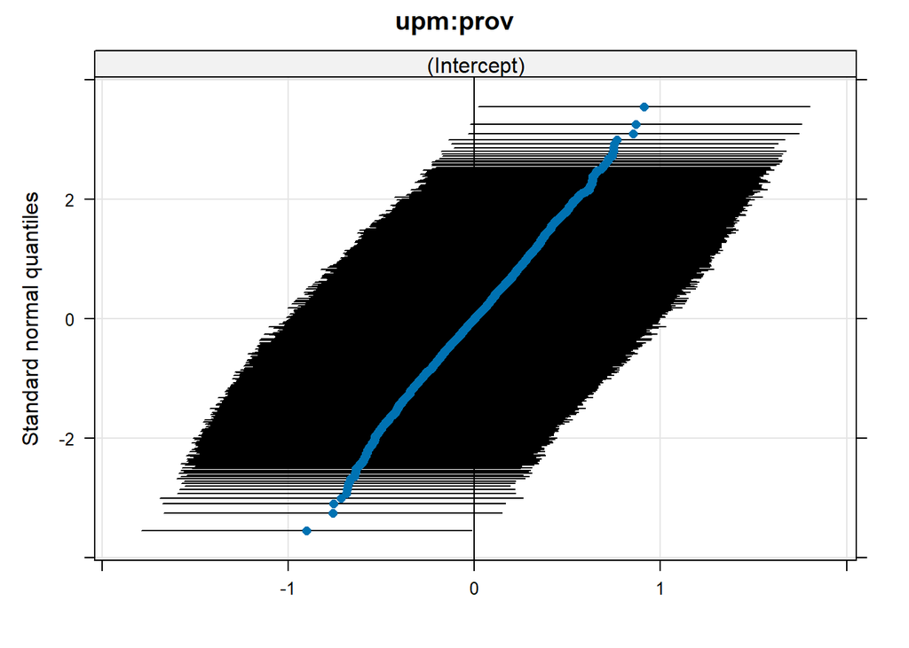

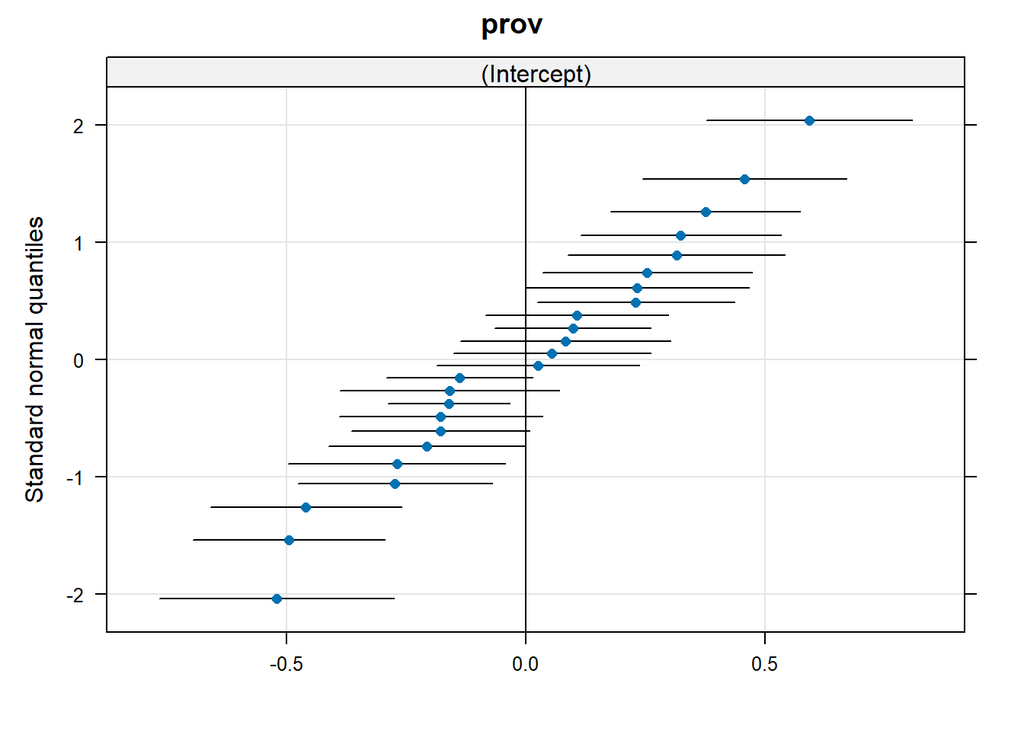

```r
qqmath(ranef(jerarquico2, condVar = TRUE))
```

# 5 Conclusiones

La violencia de género en Ecuador presenta una alta prevalencia e importantes diferencias según las características de la mujer (estado civil, educación, número de hijos, etc), pero factores como la violencia en familia de orígen y aspectos culturales como los roles de género son relacionales y de roles de género son los más relevantes.

La variabilidad encontrada entre provincias y, sobre todo, entre las unidades primarias de muestreo, evidencia que el entorno social y comunitario es un componente clave para entender la magnitud del problema, por lo que la utilización de modelos jerárquicos es muy relevante.

El uso de un modelo nulo mostró la importancia de estimar la variabilidad entre niveles, mientras que la inclusión progresiva de predictores individuales y contextuales evidenció cómo se mejora el ajuste del modelo y la capacidad explicativa.